# Praktikum 8 - Analisis Faktor

Dhea Dewanti & Nur Khamidah

## Perkenalan Analisis Faktor

Analisis Faktor (*Factor Analysis* atau FA) adalah sebuah teknik statistik yang digunakan untuk memahami hubungan antara sejumlah besar variabel yang diamati dalam satu set data dengan cara mengidentifikasi faktor-faktor yang mendasarinya. Tujuannya adalah untuk mereduksi dimensi data dengan mengidentifikasi faktor-faktor laten atau konsep yang mendasari variasi dalam data, sehingga Anda dapat memahami struktur yang mendasari data dengan lebih baik.

Beberapa hal penting yang diperhatikan dalam FA:

- FA digunakan untuk reduksi dimensi, atau mengurangi jumlah variabel yang kompleks atau terkait erat dalam satu set data menjadi sejumlah faktor yang lebih sedikit.
- Yang dimaksud dengan faktor-faktor laten adalah variabel yang tidak diamati secara langsung tetapi dapat diestimasi dari variabel-variabel yang diamati.
- FA berfokus pada mengidentifikasi faktor-faktor yang menjelaskan sebanyak mungkin variasi dalam data.
- Dalam FA, sering kali digunakan rotasi faktor untuk menginterpretasikan faktor-faktor laten yang ditemukan. Rotasi membantu dalam menentukan bagaimana faktor-faktor tersebut terhubung satu sama lain dan dengan variabel-variabel pengamatan.
- FA bisa membantu dalam pemahaman yang lebih dalam tentang data dan mengungkap pola-pola tersembunyi.

Ada 2 jenis FA:

1. *Exploratory Factor Analysis (EFA)* : digunakan untuk mengeksplorasi dan memahami hubungan antara variabel-variabel yang diamati tanpa memiliki hipotesis sebelumnya tentang bagaimana faktor-faktor terkait. Dalam EFA, akan dijawab pertanyaan seperti berapa banyak faktor yang diperlukan untuk menjelaskan variasi skor yang diamati dan bagaimana hubungan antara setiap item dengan faktor-faktor ini.
2. *Confirmatory Factor Analysis (CFA)* : digunakan untuk menguji apakah model faktor yang dihipotesiskan sesuai dengan data dengan baik. Dalam CFA terdapat teori atau hipotesis spesifik menyatakan faktor mana yang seharusnya memuat item tertentu. Dengan kata lain, dengan CFA ingin diketahui sejauh mana model yang diusulkan sesuai dengan apa yang ditemukan dalam data yang sesungguhnya.

Dalam materi kali ini, FA yang dipelajari dan dipraktikkan adalah EFA.

## Package

Beberapa *package* yang dibutuhkan dalam analisis faktor kali ini antara lain:

```r
#install.packages("psych")
#install.packages("ggcorrplot")
```

Kemudian *package* dapat digunakan dengan menjalankan baris kode berikut:

```r
library(psych)
library(ggcorrplot)
```

## Data

Data yang digunakan merupakan data pelamar kerja, di mana seorang HRD ingin mengindentifikasi faktor-faktor yang dapat menjelaskan 12 peubah yang telah dikumpulkan oleh departemen mereka untuk mengukur setiap pelamar kerja. Pegawai HRD menilai pelamar kerja dengan menggunakan skala 1 (rendah) sampai 10 (tinggi). Mereka menggumpulkan penilaian untuk 50 pelamar kerja.

```r
data_jobApp <- read.csv("https://raw.githubusercontent.com/nurkhamidah/dat/main/job-applicants.csv", sep = ";")
head(data_jobApp)
```

```
##   Academic.record Appearance Communication Company.Fit Experience Job.Fit
## 1               6          8             7           5          6       5
## 2               9          8             8           8         10       9
## 3               6          7             7           6          6       7
## 4               7          8             6           5          8       5
## 5               4          7             8           6          6       6
## 6               7          7             7           5          5       6
##   Letter Likeability Organization Potential Resume Self.Confidence
## 1      7           7            7         6      7               7
## 2      8           9            8         9      9               9
## 3      7           8            8         6      6               8
## 4      9           8            7         8      7               7
## 5      6           7            8         5      4               6
## 6      5           7            8         7      4               6
```

## Melakukan Analisis Faktor

#### Tahap 1 - Eksplorasi Data dengan Melihat Korelasi Antar Peubah

Tujuan utama melihat korelasi data dalam analisis faktor adalah untuk memahami pola hubungan antara variabel-variabel dan memastikan bahwa data yang digunakan dalam analisis faktor sesuai dan relevan. Hal ini akan membantu dalam pemilihan variabel, penentuan jumlah faktor, dan interpretasi hasil analisis faktor.

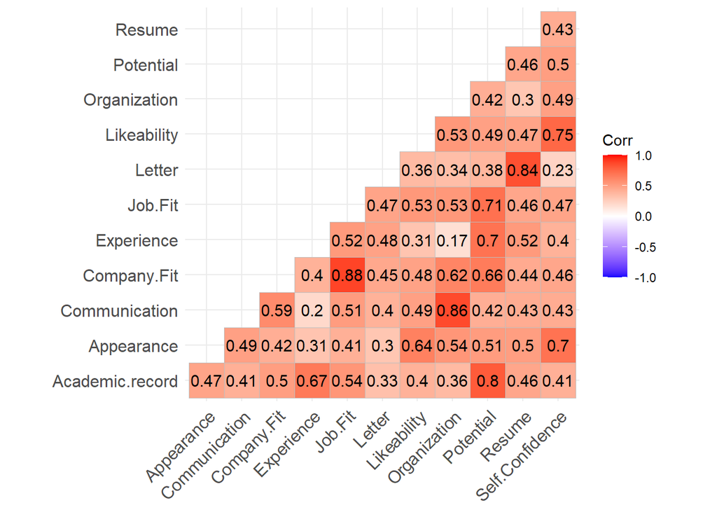

```r
cor_jobApp <- cor(data_jobApp)
ggcorrplot(cor_jobApp, type = "lower", lab = TRUE)
```

Jika diperhatikan hasil korelasi tersebut akan diperoleh beberapa kelompok peubah yang memiliki korelasi yang besar dalam kelompok peubah tersebut namun korelasinya dengan peubah diluar kelompok tersebut kecil. Sebagai ilustrasi, peubah *Potential* dengan *Academic record*, *Experience*, dan *Job Fit* memiliki korelasi yang besar dibandingkan dengan peubah lainnya. Peubah-peubah dengan korelasi tinggi ini bisa diukur dengan baik oleh suatu peubah laten yang disebut *factor*.

#### Tahap 2 - Menentukan Banyaknya Factor

Analisis Faktor di R dapat dilakukan dengan menggunakan fungsi `fa()` dari *package* `psych`. Fungsi `fa()` memiliki argumen `fm` yang menyatakan metode pendugaaan dan `rotate` yang menyatakan jenis rotasi yang digunakan. Argumen `nfactor` menyatakan banyaknya factornya.

Daftar yang bisa diisi dalam argumen `fm` adalah sebagai berikut:

| isi argumen | kegunaan |
| --- | --- |
| `minres` | komponen utama (*default*) |
| `ols` | kuadrat terkecil |
| `wls` | kuadrat terkecil terboboti |
| `gls` | kuadrat terkecil terampat |
| `pa` | metode faktor utama |
| `ml` | metode kemungkinan maksimum |
| `alpha` | analisis faktor alpha |

Daftar yang bisa diisi dalam argumen `rotate` adalah sebagai berikut:

| isi argumen | kegunaan |
| --- | --- |
| `oblimin` | direct oblimin (*default*) |
| `none` | tanpa rotasi |
| `varimax` | varimax |
| `quartimax` | quartimax |
| `equamax` | equamax |
| `promax` | promax/oblique |

Untuk kasus data pelamar kerja ini, kita akan gunakan metode pendugaan komponen utama. Banyaknya factor yang akan diduga kita set sebanyak peubah yang ada di data pelamar kerja ini.

[output not shown]

1. Penentuan banyak factor menggunakan *proportion of the sample variance explained*

```r
fa_jobApp <- fa(data_jobApp, nfactors = 12, fm = "minres", rotate = "none")
fa_jobApp$Vaccounted
```

```
##                             MR1       MR2        MR3        MR4        MR5
## SS loadings           6.2782307 1.3820643 1.02167387 0.94565013 0.52627793
## Proportion Var        0.5231859 0.1151720 0.08513949 0.07880418 0.04385649
## Cumulative Var        0.5231859 0.6383579 0.72349741 0.80230159 0.84615808
## Proportion Explained  0.5886699 0.1295874 0.09579589 0.08866762 0.04934575
## Cumulative Proportion 0.5886699 0.7182573 0.81405323 0.90272085 0.95206660
##                              MR6        MR7         MR8         MR9        MR10
## SS loadings           0.22747415 0.11983572 0.085960317 0.060410456 0.016491825
## Proportion Var        0.01895618 0.00998631 0.007163360 0.005034205 0.001374319
## Cumulative Var        0.86511426 0.87510057 0.882263932 0.887298136 0.888672455
## Proportion Explained  0.02132881 0.01123624 0.008059954 0.005664306 0.001546334
## Cumulative Proportion 0.97339541 0.98463165 0.992691601 0.998355907 0.999902241
##                               MR11         MR12
## SS loadings           1.042615e-03 1.200000e-29
## Proportion Var        8.688458e-05 1.000000e-30
## Cumulative Var        8.887593e-01 8.887593e-01
## Proportion Explained  9.775940e-05 1.125164e-30
## Cumulative Proportion 1.000000e+00 1.000000e+00
```

**MR1** sampai **MR12** merupakan nama dari faktor-faktor yang telah diekstrasksi. Kemudian, **SS loadings** merupakan keragamaan dari masing-masing factor.

Jika dilihat pada *Cumulative Proportion*, dengan menggunakan 2 factor saja sudah bisa menjelaskan lebih dari 71% keragamaan dari data asal. Namun, penambahan *Cumulative Proportion* dari penggunaan faktor 2 sampai faktor 4 masih cukup besar sehingga masih masuk akal untuk menggunakan 4 factor.

2. Menggunakan *scree plot*

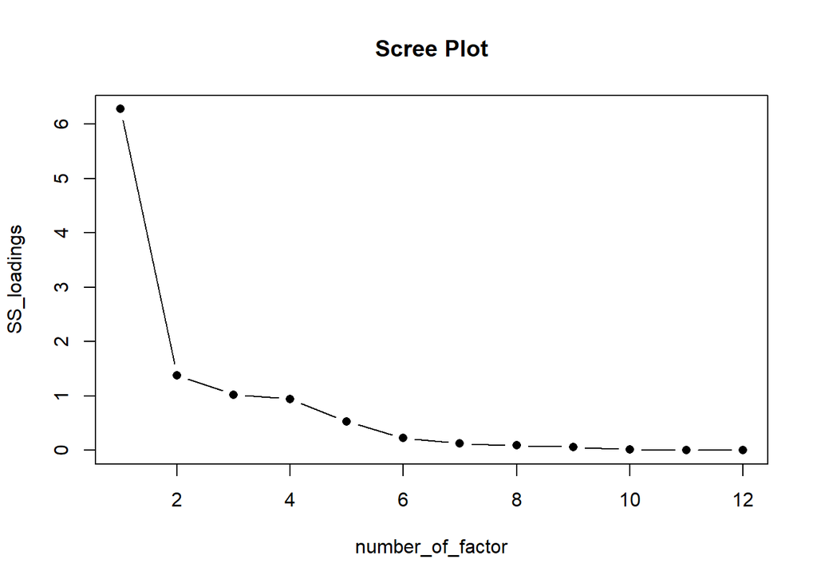

```r
SS_loadings <- fa_jobApp$Vaccounted[1,]
number_of_factor <- seq_along(SS_loadings)
plot(number_of_factor, SS_loadings, type = "b", main = "Scree Plot", pch = 16)
```

Berdasarkan *scree plot*, pola garis yang berbentuk seperti siku tangan berada pada factor kedua. Sehingga menurut *scree plot* cukup 2 factor saja yang digunakan.

Karena menurut *scree plot* dan *proportion of variance explained* berbeda, akan dicoba keduanya dan melihat factor mana yang lebih mudah diinterpretasikan.

#### Tahap 3 - Estimasi Factor Loading (Menggunakan 4 Factor)

```r
fa_jobApp4 <- fa(data_jobApp, nfactors = 4, fm = "minres", rotate = "none")
print(fa_jobApp4$loadings, cut = 0)
```

```
##
## Loadings:
##                 MR1    MR2    MR3    MR4
## Academic.record  0.698  0.236 -0.304 -0.038
## Appearance       0.692 -0.222 -0.036  0.350
## Communication    0.696 -0.393  0.219 -0.211
## Company.Fit      0.786 -0.074 -0.042 -0.360
## Experience       0.623  0.489 -0.220  0.036
## Job.Fit          0.794  0.045 -0.113 -0.293
## Letter           0.633  0.411  0.599 -0.032
## Likeability      0.713 -0.240 -0.010  0.311
## Organization     0.703 -0.534  0.155 -0.231
## Potential        0.814  0.238 -0.400 -0.108
## Resume           0.708  0.353  0.424  0.216
## Self.Confidence  0.707 -0.251 -0.155  0.451
##
##                  MR1   MR2   MR3   MR4
## SS loadings    6.152 1.262 0.953 0.798
## Proportion Var 0.513 0.105 0.079 0.067
## Cumulative Var 0.513 0.618 0.697 0.764
```

Jika kita perhatikan, nilai factor loading yang besar berkumpul di peubah factor yang **pertama**, sehingga akan sulit untuk menginterpretasikan factor 2 sampai factor 4. Oleh karena itu, kita bisa melakukan rotasi faktor agar lebih mudah menginterpretasikanya.

| Note: |
| --- |
| Argumen `cut=0` berarti kita menampilkan semua factor loading, jika kita tidak tentukan isi dari argumen `cut`, secara default R tidak menampilkan nilai yang berkisar antara [-0.1, 0.1] |

#### Tahap 3 - Estimasi Factor Loading (Menggunakan 2 Factor)

```r
fa_jobApp2 <- fa(data_jobApp, nfactors = 2, fm = "minres", rotate = "none")
print(fa_jobApp2$loadings, cut = 0)
```

```
##
## Loadings:
##                 MR1    MR2
## Academic.record  0.703  0.305
## Appearance       0.683 -0.172
## Communication    0.699 -0.434
## Company.Fit      0.778 -0.067
## Experience       0.637  0.578
## Job.Fit          0.792  0.063
## Letter           0.581  0.165
## Likeability      0.707 -0.198
## Organization     0.708 -0.548
## Potential        0.807  0.304
## Resume           0.670  0.187
## Self.Confidence  0.682 -0.143
##
##                  MR1   MR2
## SS loadings    5.993 1.169
## Proportion Var 0.499 0.097
## Cumulative Var 0.499 0.597
```

Untuk dua faktor pun, nilai factor loading yang besar terkumpul pada faktor pertama sehingga akan sulit diinterpretasikan. Oleh karena itu, kita akan melakukan rotasi faktor untuk penggunaan dua factor ini.

| Note: |
| --- |
| Ukuran besar atau kecil dari factor loading itu relatif. Beberapa buku menyebutkan nilai diatas 0.6 sudah besar. |

#### Tahap 4 - Rotasi Factor (Menggunakan 4 Factor)

```r
fa_jobApp4_rotate <- fa(data_jobApp, nfactors = 4, fm = "minres", rotate = "varimax")
print(fa_jobApp4_rotate$loadings, cut = 0)
```

```
##
## Loadings:
##                 MR1    MR2    MR4    MR3
## Academic.record  0.713  0.178  0.269  0.154
## Appearance       0.230  0.272  0.704  0.171
## Communication    0.117  0.760  0.309  0.208
## Company.Fit      0.521  0.652  0.151  0.187
## Experience       0.732 -0.032  0.180  0.327
## Job.Fit          0.614  0.531  0.170  0.206
## Letter           0.223  0.243  0.059  0.904
## Likeability      0.226  0.321  0.688  0.185
## Organization     0.093  0.843  0.360  0.087
## Potential        0.855  0.257  0.285  0.118
## Resume           0.286  0.129  0.331  0.802
## Self.Confidence  0.273  0.210  0.816  0.085
##
##                  MR1   MR2   MR4   MR3
## SS loadings    2.757 2.392 2.211 1.806
## Proportion Var 0.230 0.199 0.184 0.151
## Cumulative Var 0.230 0.429 0.613 0.764
```

Setelah dirotasi menggunakan metode **varimax**, terlihat bahwa factor loadings tidak yang bernilai besar tidak lagi berkumpul pada satu faktor saja sehingga memungkinkan diinterpretasikan untuk setiap faktor yang terbentuk.

Fitur lain yang menarik untuk dibahas dalam analisis factor adalah *Communality*. *Communality* menjelaskan tentang banyaknya keragamaan yang dapat dijelaskan oleh factor untuk masing-masing peubah asal. Semakin nilainya mendekati satu semakin baik keragamaan yang dapat dijelaskan.

```r
fa_jobApp4_rotate$communalities
```

```
## Academic.record      Appearance   Communication     Company.Fit      Experience
##       0.6361963       0.6523914       0.7303190       0.7542383       0.6772272
##         Job.Fit          Letter     Likeability    Organization       Potential
##       0.7309871       0.9299102       0.6622484       0.8570245       0.8914205
##          Resume Self.Confidence
##       0.8520531       0.7911206
```

Dalam penggunan 4 factor ini nilai *communality* untuk semua peubah asal bernilai besar (lebih dari 0.6) sehingga dengan penggunaan 4 faktor sudah tepat.

#### Tahap 4 - Rotasi Factor (Menggunakan 2 Factor)

```r
fa_jobApp2_rotate <- fa(data_jobApp, nfactors = 2, fm = "minres", rotate = "varimax")
print(fa_jobApp2_rotate$loadings, cut = 0)
```

```
##
## Loadings:
##                 MR1   MR2
## Academic.record 0.282 0.712
## Appearance      0.605 0.361
## Communication   0.802 0.187
## Company.Fit     0.598 0.503
## Experience      0.042 0.859
## Job.Fit         0.516 0.604
## Letter          0.294 0.527
## Likeability     0.640 0.359
## Organization    0.888 0.112
## Potential       0.356 0.785
## Resume          0.342 0.606
## Self.Confidence 0.584 0.381
##
##                  MR1   MR2
## SS loadings    3.583 3.579
## Proportion Var 0.299 0.298
## Cumulative Var 0.299 0.597
```

Untuk penggunaan dua factor juga akan nilai factor loadings yang besar sudah tersebar. Oleh karena itu memungkinkan diinterpretasikan.

```r
fa_jobApp2_rotate$communalities
```

```
## Academic.record      Appearance   Communication     Company.Fit      Experience
##       0.5867947       0.4963696       0.6774295       0.6104035       0.7404683
##         Job.Fit          Letter     Likeability    Organization       Potential
##       0.6313752       0.3644644       0.5383605       0.8015258       0.7437662
##          Resume Self.Confidence
##       0.4843980       0.4859770
```

Dalam penggunan 2 factor ini nilai *communality* untuk terdapat peubah asal bernilai kecil (kurang dari 0.4) sehingga dengan penggunaan 2 factor kurang tepat.

Dalam hal ini lebih baik menggunakan 4 factor saja, namun dalam ilustrasi ini 2 factor akan tetap digunakan untuk memperlihatkan perbedaan interpretasi dalam pemilihan banyaknya faktor digunakan.

| Note: |
| --- |
| *Communalities* bisa diperiksa saat sebelum kita melakukan rotasi. |

#### Tahap 5 - Interpretasi Factor (Menggunakan 4 Factor)

Untuk mempermudah interpretasi, factor loading yang ditampilkan selain [-0.6, 0.6].

```r
print(fa_jobApp4_rotate$loadings, cut = 0.6)
```

```
##
## Loadings:
##                 MR1    MR2    MR4    MR3
## Academic.record  0.713
## Appearance                     0.704
## Communication           0.760
## Company.Fit             0.652
## Experience       0.732
## Job.Fit          0.614
## Letter                                0.904
## Likeability                    0.688
## Organization            0.843
## Potential        0.855
## Resume                                0.802
## Self.Confidence                0.816
##
##                  MR1   MR2   MR4   MR3
## SS loadings    2.757 2.392 2.211 1.806
## Proportion Var 0.230 0.199 0.184 0.151
## Cumulative Var 0.230 0.429 0.613 0.764
```

Pada penggunaan 4 factor, factor laoding hasil rotasi dapat diinterpretasikan sebagai berikut:

1. *Accademic Records*, *Experience*, *Job Fit*, dan *Potential* memiliki nilai factor loading yang besar dan positif untuk factor 1, kita bisa menyebut factor 1 sebagai **ketepatan penempatan dan potensi berkembang bagi pegawai dalam perusahaan**.
2. *Communication*, *Company Fit*, dan *Organization* memiliki nilai factor loading yang besar dan positif untuk factor 2 sehingga kita bisa menyebut factor 2 dengan **kemampuan dalam bekerja (*work skills*)**.
3. *Letter* dan *Resume* memiliki nilai factor loading yang besar dan positif untuk factor 3 sehingga kita bisa menyebut factor 3 dengan **kemampuan menulis**.
4. *Appearance*, *Likeability*, and *Self Confidence* memiliki nilai factor loading yang besar dan positif untuk faktor 4 sehingga kita bisa menyebut factor 4 dengan **kualitas personal pegawai**.

#### Tahap 5 - Interpretasi Factor (Menggunakan 2 Factor)

```r
print(fa_jobApp2_rotate$loadings, cut = 0.6)
```

```
##
## Loadings:
##                 MR1   MR2
## Academic.record       0.712
## Appearance      0.605
## Communication   0.802
## Company.Fit
## Experience            0.859
## Job.Fit               0.604
## Letter
## Likeability     0.640
## Organization    0.888
## Potential             0.785
## Resume                0.606
## Self.Confidence
##
##                  MR1   MR2
## SS loadings    3.583 3.579
## Proportion Var 0.299 0.298
## Cumulative Var 0.299 0.597
```

Pada penggunaan 2 factor, factor laoding hasil rotasi dapat diinterpretasikan sebagai berikut:

1. *Appearance*, *Communication*, *Likeability*, dan *Organization* memiliki nilai factor loading yang besar dan positif untuk factor 1, kita bisa menyebut factor 1 sebagai *soft-skill* dari pegawai.
2. *Academic Record*, *Experience*, *Job Fit*, *Potential*, dan *Resume* memiliki nilai factor loading yang besar dan positif untuk factor 2, kita bisa menyebut factor 2 sebagai *hard-skill* dari pegawai.

Berdasarkan penggunaan 4 factor dan 2 factor diperoleh interpretasi yang berbeda dari factor-factor yang dihasilkan. Sehingga penggunaan 4 factor atau 2 factor bisa disesuaikan dengan kebutuhan perusahaan tersebut.

[output not shown]